# COMP47670 Assignment 1 Sample - Task 2

### Temperature Analysis

First we will look at temperature data. We could just look at the raw statistics for the different cities. We'll create function to do this, so that we can reuse it later.

```python
df_temp_stats = compute_stats("Temperature")
df_temp_stats
```

| City | Min | Max | Mean | Median |
| --- | --- | --- | --- | --- |
| Dublin | 1.1 | 17.2 | 7.31 | 7.8 |
| Lisbon | 8.9 | 19.4 | 14.96 | 15.0 |
| London | 0.0 | 15.6 | 8.47 | 8.3 |
| Rome | 2.8 | 19.4 | 13.82 | 14.4 |

We could look at plots for each of the different cities separately, at hourly intervals:

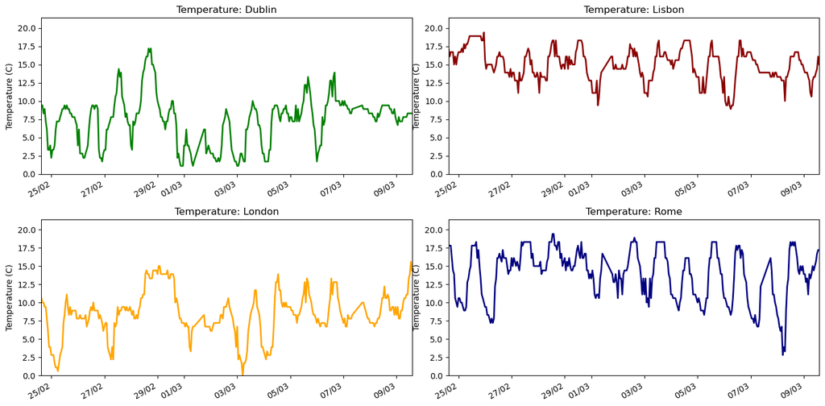

```python
fig = plt.figure(figsize=(14,7))
for i, city_name in enumerate(city_names):
    axc = fig.add_subplot(2, 2, i+1)
    ax = df_cities[city_name]["Temperature"].plot(ax=axc, legend=False, lw=2, color=city_colors[city_name])
    ax.set_title("Temperature: %s" % city_name)
    ax.set_ylabel("Temperature (C)")
    # note that we will use consistent Y-axis limits based on the ranges we computed above
    ax.set_ylim(0, df_temp_stats["Max"].max()+2)
    ax.set_xlim(df_cities[city_name].index.min(), df_cities[city_name].index.max())
    # change the format of the dates on the x-axis
    ax.xaxis.set_major_formatter(mdates.DateFormatter('%d/%m'))
# fix the spacing between plots
fig.tight_layout()
```

```python
df_daily_temps = {}
for city_name in city_names:
    # groupy each index by day
    groups = df_cities[city_name]["Temperature"].groupby(pd.Grouper(freq='D'))
    min_temps = groups.min()
    max_temps = groups.max()
    # combine the min and max daily values into a new DataFrame
    df_daily_temps[city_name] = pd.DataFrame({"Min": min_temps, "Max": max_temps})
```

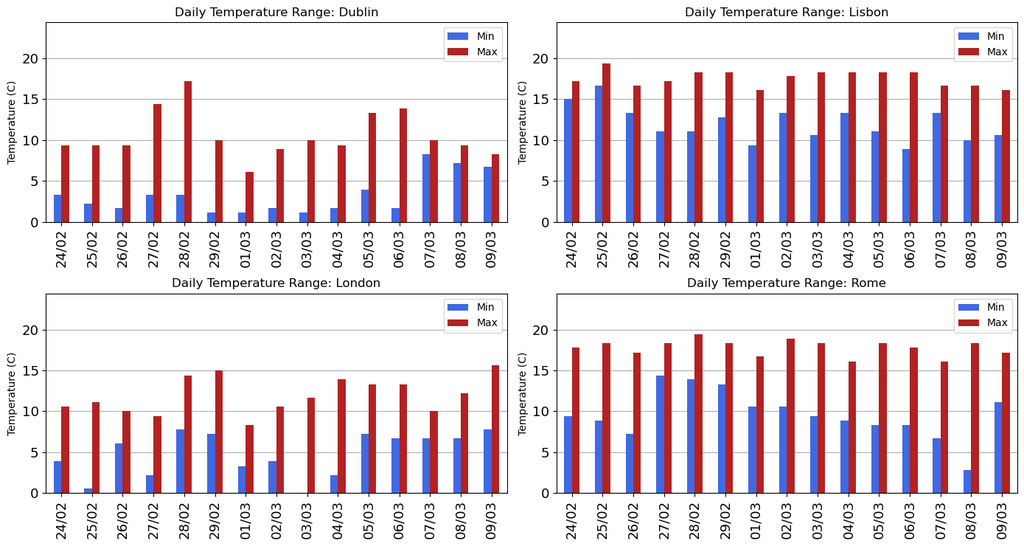

```python
fig = plt.figure(figsize=(14,7.5))
for i, city_name in enumerate(city_names):
    axc = fig.add_subplot(2, 2, i+1)
    ax = df_daily_temps[city_name].plot.bar(ax=axc, y=['Min', 'Max'],
        color={ "Min": "royalblue", "Max": "firebrick"}, fontsize=fontsize, zorder=3)
    # generate nicer x-axis labels
    ticklabels = [ d.strftime("%d/%m") for d in df_daily_temps[city_name].index]
    ax.xaxis.set_major_formatter(ticker.FixedFormatter(ticklabels))
    ax.set_title("Daily Temperature Range: %s" % city_name)
    ax.set_ylabel("Temperature (C)")
    # again make the y-axis ranges consistent
    ax.set_ylim(0, df_temp_stats["Max"].max()+5)
    ax.yaxis.grid(True);
# fix the spacing between plots
fig.tight_layout()
```

In the period covered the temperatures were lower in Dublin and London and there seemed to be significantly more variation as well.  
The temperature was warmer and more stable in Lisbon.